# assignment1

Diagnosis: Histogram or Q–Q plot of residuals. Formal tests like Shapiro–Wilk or Kolmogorov–Smirnov can be used.

```r
set.seed(42)
n <- 1000
x <- 1:n

# Changeable parameters
# - Change the parameters to affect the generated data points below.
# - You may copy this code multiple times to answer all the questions in the exercise.
# - You may find it reasonable to argue for multiple violations from a single generated set of data points.

contant <- 0
trend <- 0
curve_magnitue <- 0
curve_period <- 100
curve_shift <- 0
normal_noise_magnitue <- 1
norm_noise_periode <- 10000
shift_norm_noise <- 500
non_normal_noise_magnitue <- 0
non_norm_noice_periode <- 10000
shift_non_norm_noise <- 500

# put y.gen into a function
y_gen <- function(
    contant, trend, curve_magnitue, curve_period,
    curve_shift, normal_noise_magnitue, norm_noise_periode,
    shift_norm_noise, non_normal_noise_magnitue,
    non_norm_noice_periode, shift_non_norm_noise
    ){
  contant + trend * x +
  curve_magnitue * sin((x/curve_period + curve_shift)*pi) +
  normal_noise_magnitue*cos((
    x / norm_noise_periode + shift_norm_noise/norm_noise_periode)*pi
    )*rnorm(n, sd = 3) +
  non_normal_noise_magnitue*cos(
    (x/non_norm_noice_periode + shift_non_norm_noise/non_norm_noice_periode)*pi
  ) * rexp(n, rate = 0.2)
  }
```

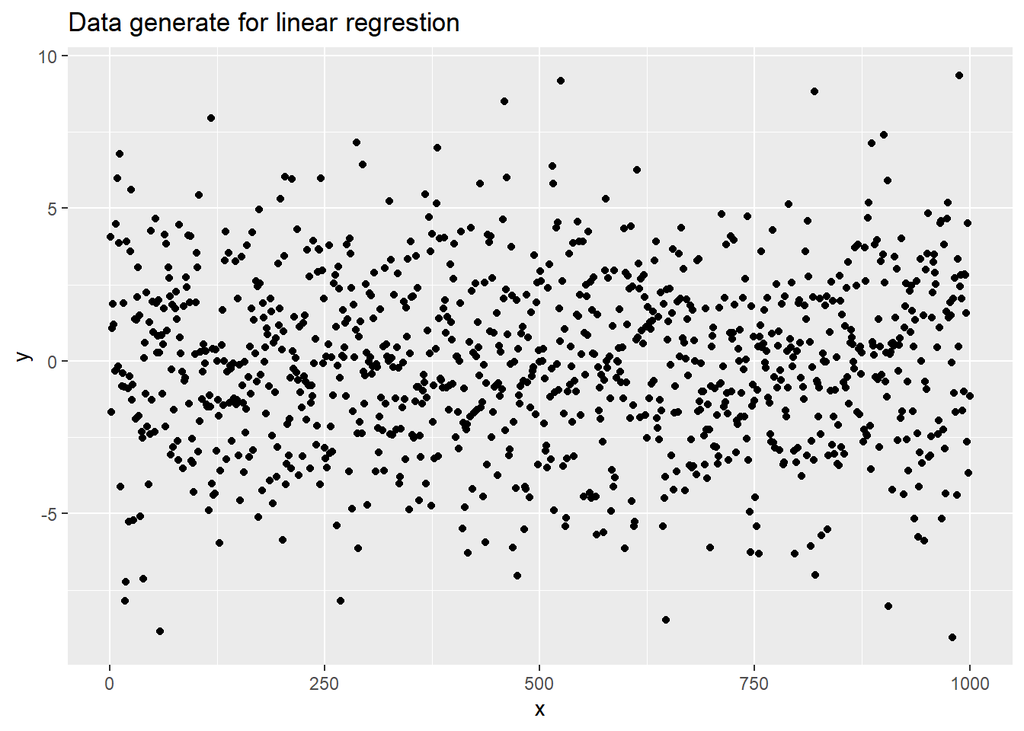

```r
y.gen <- y_gen(contant, trend, curve_magnitue, curve_period,
               curve_shift, normal_noise_magnitue, norm_noise_periode,
               shift_norm_noise, non_normal_noise_magnitue,
               non_norm_noice_periode, shift_non_norm_noise)

p <- qplot(x, y.gen, ylab = "y") +
  geom_point(size = 0.1) +
  labs(title = "Data generate for linear regrestion")
# Display the plot
print(p)
```

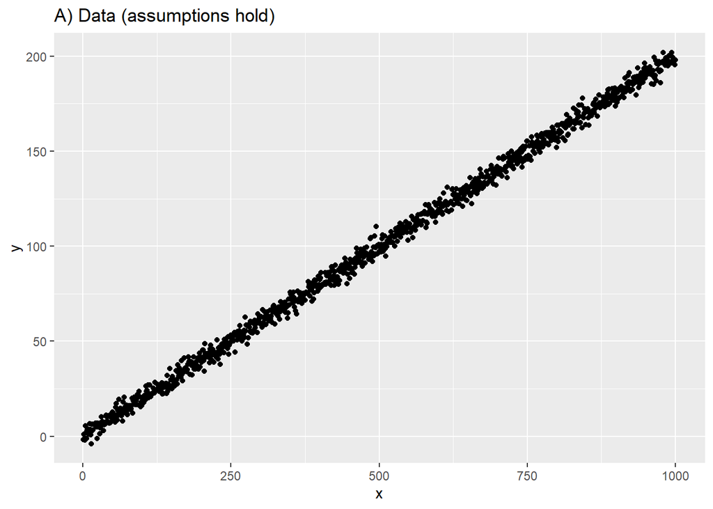

```r
# ---- A: All assumptions hold ----
set.seed(1)

contant <- 0
trend <- 0.2                # linear trend
curve_magnitue <- 0           # no curvature
curve_period <- 100
curve_shift <- 0
normal_noise_magnitue <- 1
norm_noise_periode <- 1e9     # ~constant variance (cos ~ 1)
shift_norm_noise <- 0
non_normal_noise_magnitue <- 0
non_norm_noice_periode <- 1e9
shift_non_norm_noise <- 0

y.gen <- y_gen(
  contant=contant, trend=trend, curve_magnitue=curve_magnitue, curve_period=curve_period,
  curve_shift=curve_shift, normal_noise_magnitue=normal_noise_magnitue, norm_noise_periode=norm_noise_periode,
  shift_norm_noise=shift_norm_noise, non_normal_noise_magnitue=non_normal_noise_magnitue,
  non_norm_noice_periode=non_norm_noice_periode, shift_non_norm_noise=shift_non_norm_noise
)

qplot(x, y.gen) + geom_point(size=0.1) + labs(title="A) Data (assumptions hold)", y="y")
```

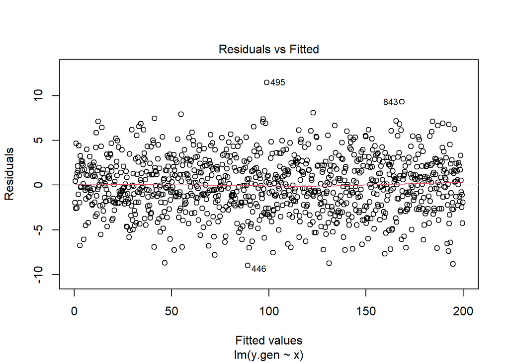

```r
lm.gen <- lm(y.gen ~ x)
plot(lm.gen, which = 1)  # Residuals vs Fitted (should be patternless)
```

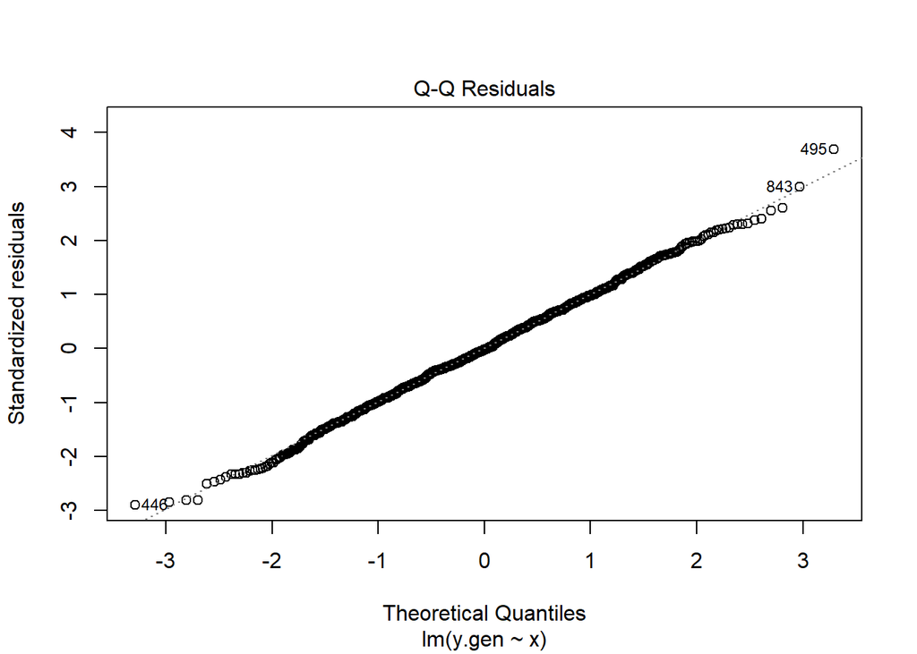

```r
plot(lm.gen, which = 2)  # Q-Q (close to line)
```

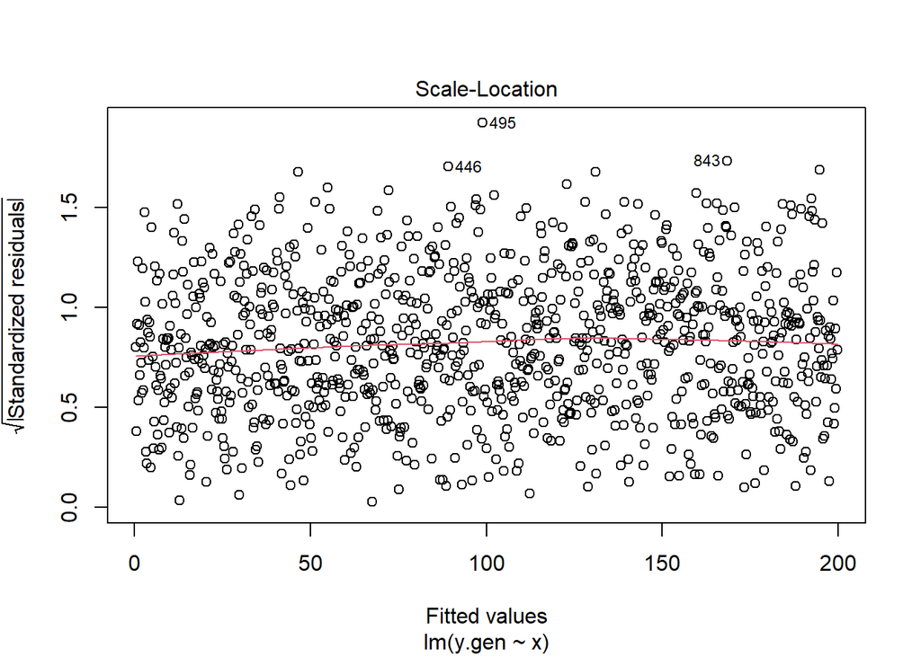

```r
plot(lm.gen, which = 3)  # Scale-Location (flat-ish)
```

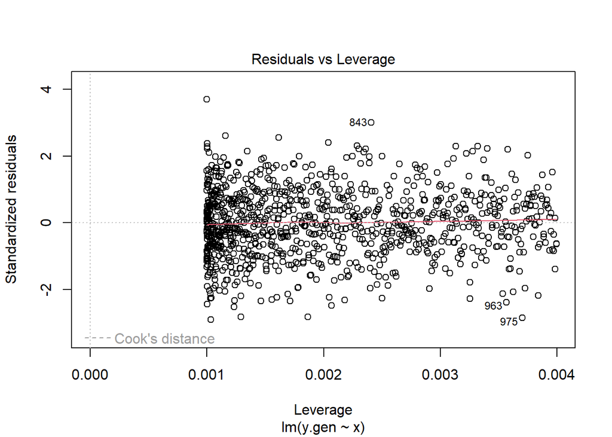

```r
plot(lm.gen, which = 5)  # Leverage (no standout points)
```

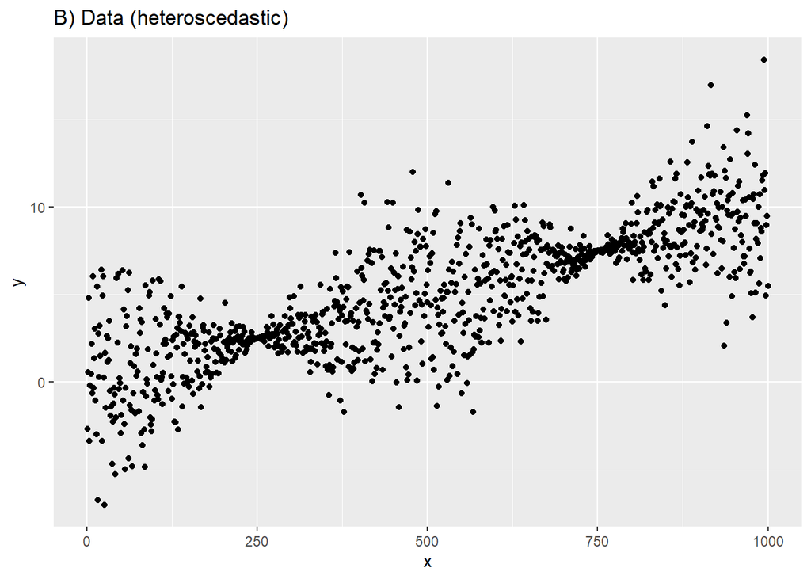

```r
# ---- B: Heteroscedasticity ----
set.seed(2)

contant <- 0
trend <- 0.01
curve_magnitue <- 0
curve_period <- 100
curve_shift <- 0
normal_noise_magnitue <- 1
norm_noise_periode <- 500      # variance oscillates strongly across x
shift_norm_noise <- 0
non_normal_noise_magnitue <- 0
non_norm_noice_periode <- 1e9
shift_non_norm_noise <- 0

y.gen <- y_gen(
  contant=contant, trend=trend, curve_magnitue=curve_magnitue, curve_period=curve_period,
  curve_shift=curve_shift, normal_noise_magnitue=normal_noise_magnitue, norm_noise_periode=norm_noise_periode,
  shift_norm_noise=shift_norm_noise, non_normal_noise_magnitue=non_normal_noise_magnitue,
  non_norm_noice_periode=non_norm_noice_periode, shift_non_norm_noise=shift_non_norm_noise
)

qplot(x, y.gen) + geom_point(size=0.1) + labs(title="B) Data (heteroscedastic)", y="y")
```

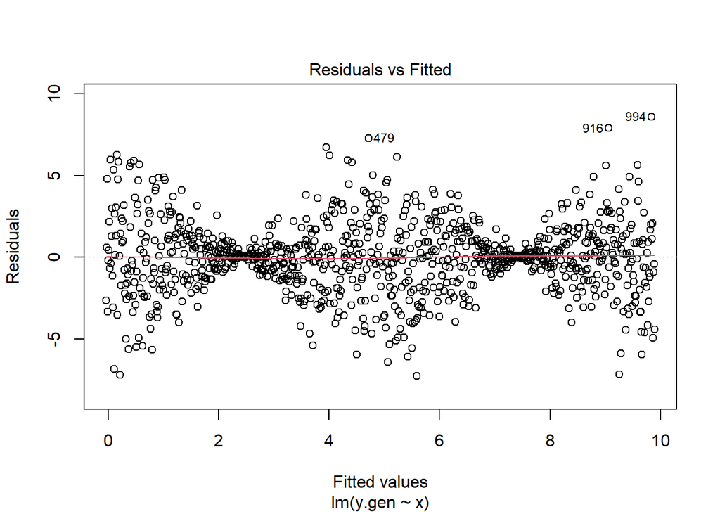

```r
lm.gen <- lm(y.gen ~ x)
plot(lm.gen, which = 1)  # Residuals vs Fitted: changing spread (violates homoscedasticity)
```

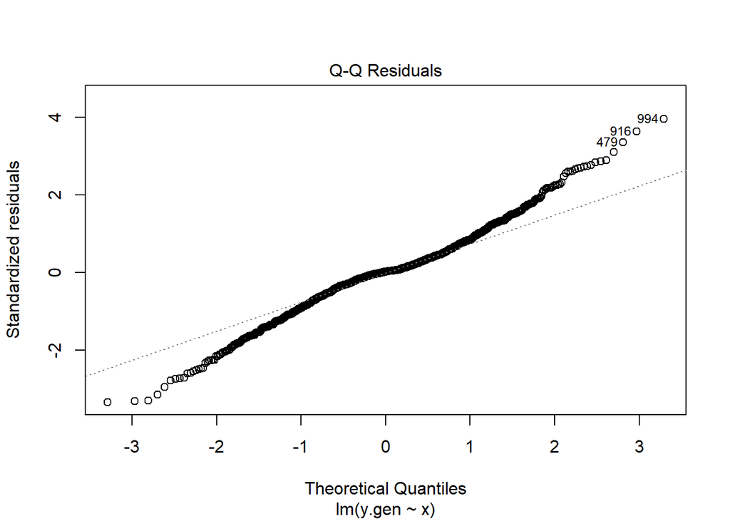

```r
plot(lm.gen, which = 2)  # Q-Q
```

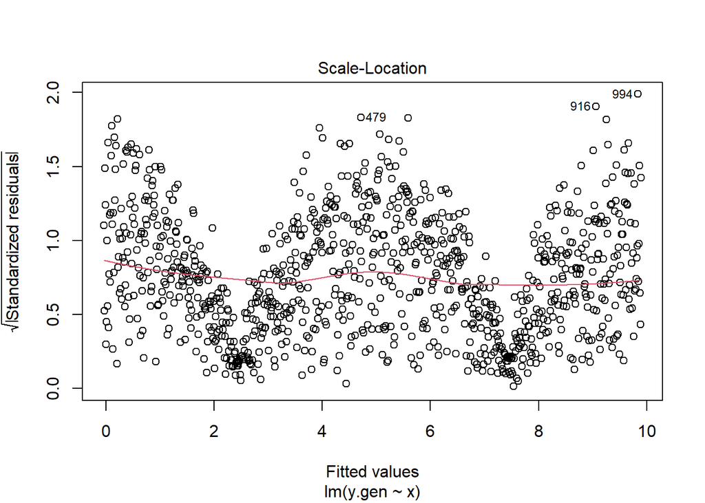

```r
plot(lm.gen, which = 3)  # Scale-Location: upward/downward pattern (non-constant variance)
```

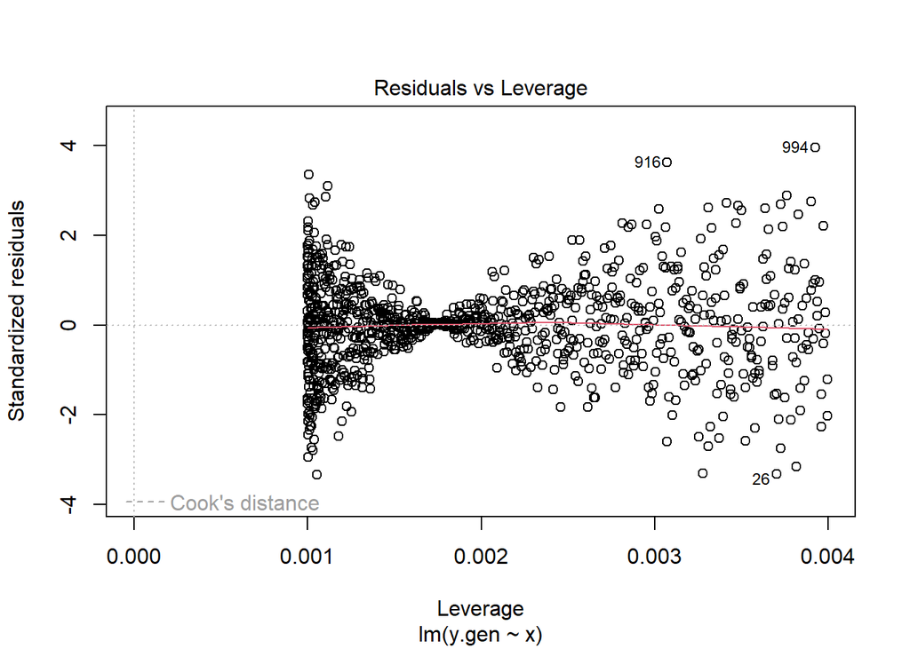

```r
plot(lm.gen, which = 5)  # Leverage
```

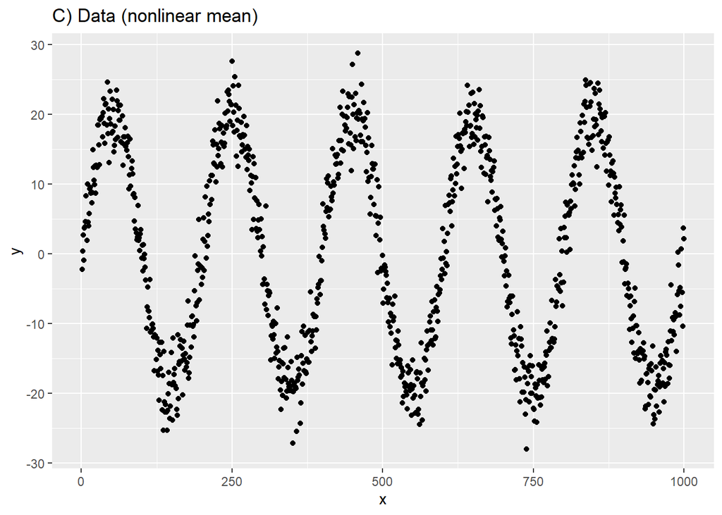

```r
# ---- C: Nonlinearity ----
set.seed(3)

contant <- 0
trend <- 0.0                  # keep linear part minimal to expose curvature
curve_magnitue <- 20          # visible curvature
curve_period <- 100           # periodic curve in mean
curve_shift <- 0
normal_noise_magnitue <- 1
norm_noise_periode <- 1e9     # ~constant variance to isolate nonlinearity
shift_norm_noise <- 0
non_normal_noise_magnitue <- 0
non_norm_noice_periode <- 1e9
shift_non_norm_noise <- 0

y.gen <- y_gen(
  contant=contant, trend=trend, curve_magnitue=curve_magnitue, curve_period=curve_period,
  curve_shift=curve_shift, normal_noise_magnitue=normal_noise_magnitue, norm_noise_periode=norm_noise_periode,
  shift_norm_noise=shift_norm_noise, non_normal_noise_magnitue=non_normal_noise_magnitue,
  non_norm_noice_periode=non_norm_noice_periode, shift_non_norm_noise=shift_non_norm_noise
)

qplot(x, y.gen) + geom_point(size=0.1) + labs(title="C) Data (nonlinear mean)", y="y")
```

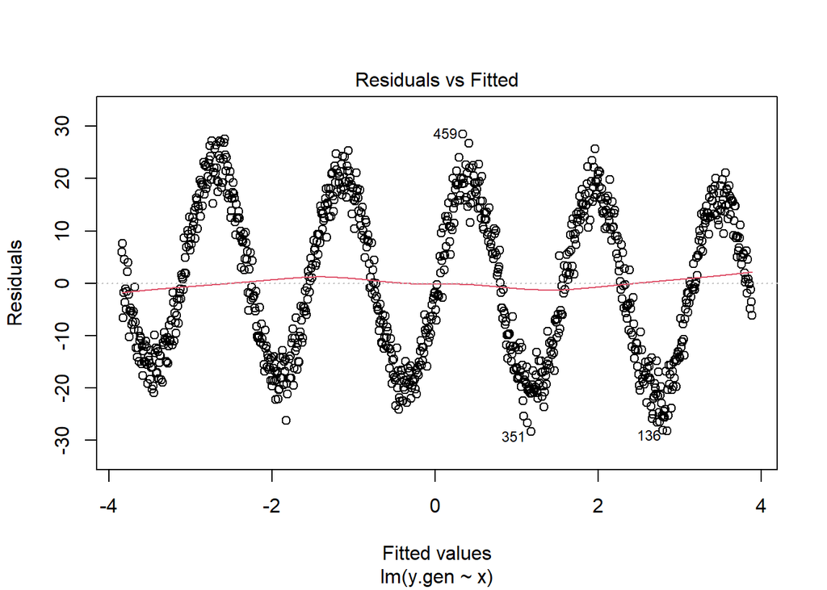

```r
lm.gen <- lm(y.gen ~ x)
plot(lm.gen, which = 1)  # Residuals vs Fitted: curved pattern (violates linearity)
```

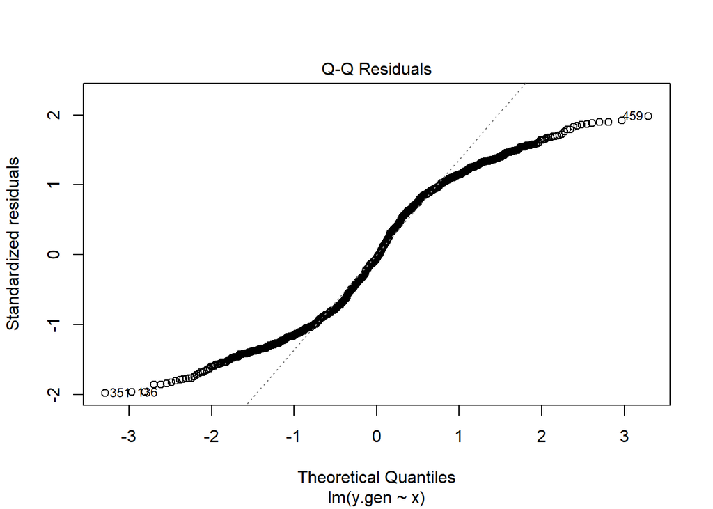

```r
plot(lm.gen, which = 2)  # Q-Q
```

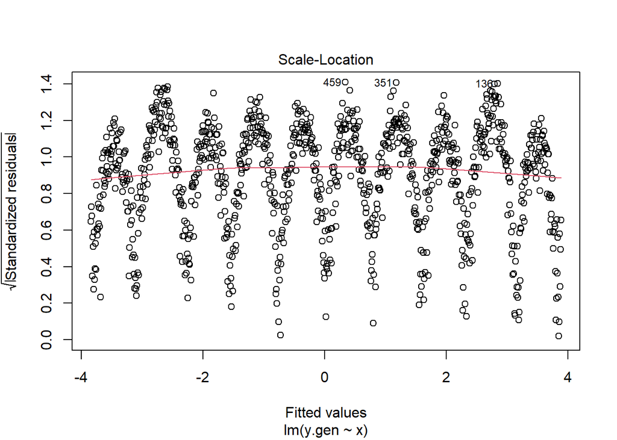

```r
plot(lm.gen, which = 3)  # Scale-Location
```

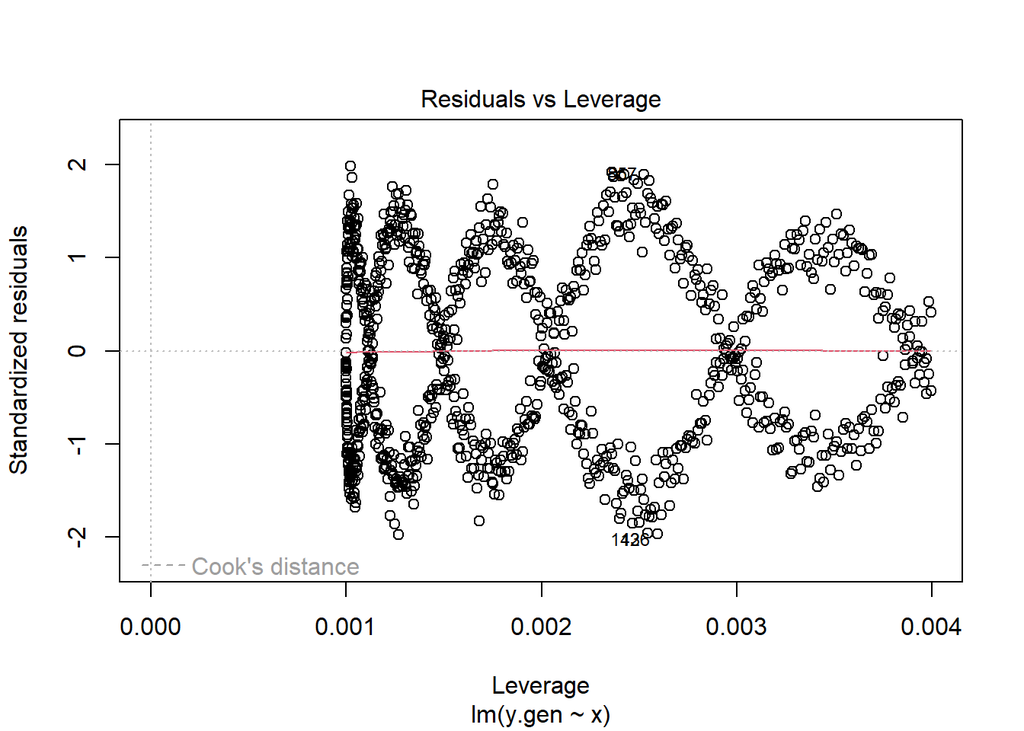

```r
plot(lm.gen, which = 5)  # Leverage
```

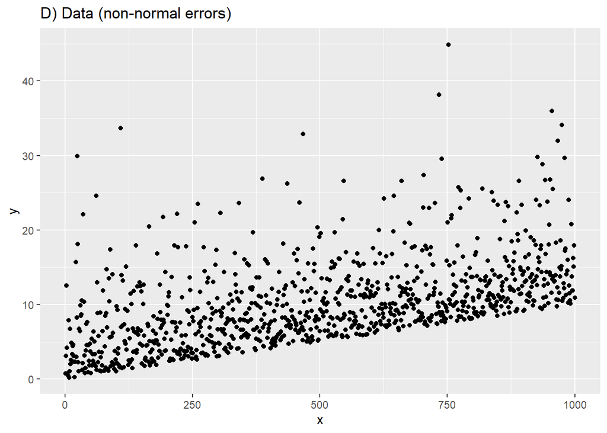

```r
# ---- D: Non-normal residuals ----
set.seed(4)

contant <- 0
trend <- 0.01
curve_magnitue <- 0
curve_period <- 100
curve_shift <- 0
normal_noise_magnitue <- 0     # turn off normal part to isolate non-normality
norm_noise_periode <- 1e9
shift_norm_noise <- 0
non_normal_noise_magnitue <- 1 # exponential noise component on
non_norm_noice_periode <- 1e9  # ~constant scale
shift_non_norm_noise <- 0

y.gen <- y_gen(
  contant=contant, trend=trend, curve_magnitue=curve_magnitue, curve_period=curve_period,
  curve_shift=curve_shift, normal_noise_magnitue=normal_noise_magnitue, norm_noise_periode=norm_noise_periode,
  shift_norm_noise=shift_norm_noise, non_normal_noise_magnitue=non_normal_noise_magnitue,
  non_norm_noice_periode=non_norm_noice_periode, shift_non_norm_noise=shift_non_norm_noise
)

qplot(x, y.gen) + geom_point(size=0.1) + labs(title="D) Data (non-normal errors)", y="y")
```

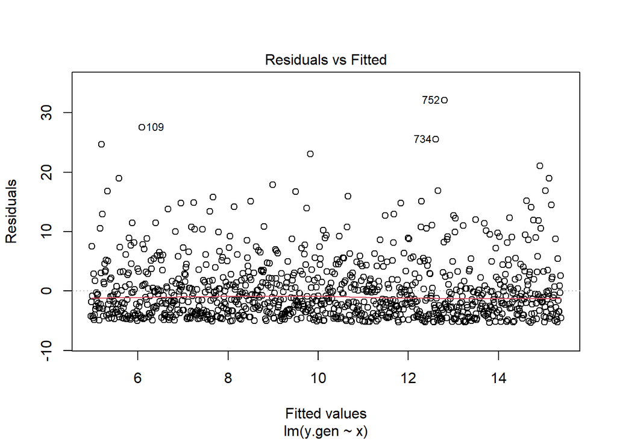

```r
lm.gen <- lm(y.gen ~ x)
plot(lm.gen, which = 1)  # Residuals vs Fitted
```

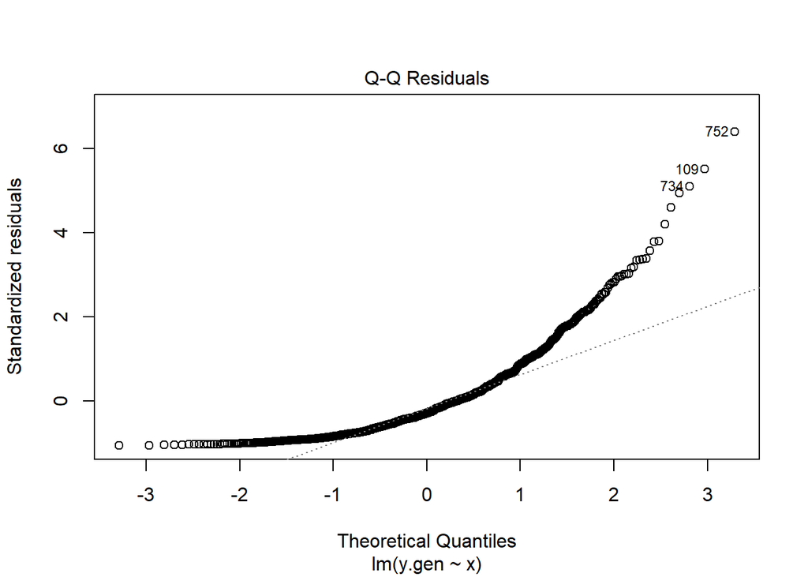

```r
plot(lm.gen, which = 2)  # Q-Q: systematic deviations (skew/heavy tails)
```

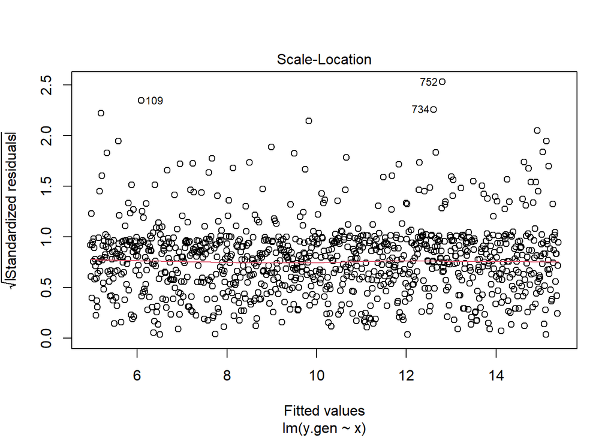

```r
plot(lm.gen, which = 3)  # Scale-Location
```

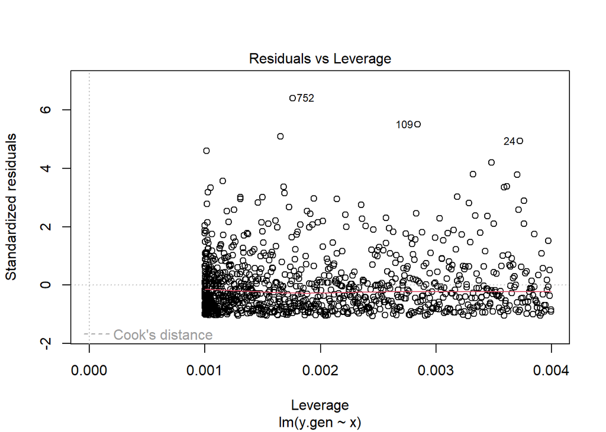

```r
plot(lm.gen, which = 5)  # Leverage
```

1. Linearity violated

What we see: Residuals vs Fitted shows a systematic curve/wave (not a random cloud around 0). The linear fit is biased because it tries to force a line through a curved signal.

2. Homoscedasticity violated

What it means: The error variance changes with 𝑋 (heteroscedasticity).

In the generator: Make the noise scale depend on 𝑋 (e.g., cosine envelope via norm_noise_periode/shift_norm_noise, so the spread oscillates with 𝑥).

What we see: Residuals vs Fitted (and Scale–Location) show changing spread—funnel shapes or periodic widening/narrowing. Coefficient SEs become unreliable unless you use robust SEs or model the variance.

3. Independence violated

What it means: Errors are correlated across observations (common with time index 𝑥=1:𝑛x=1:n).

In the data: If errors contain persistence/seasonality (e.g., any serial pattern in the noise term), residuals at nearby 𝑥 x are autocorrelated.

What we see: Residuals vs Fitted may show runs; an ACF of residuals has significant lags; Durbin–Watson deviates from ~2. Consequence: SEs are understated and tests overstate significance. (OLS estimates remain unbiased if regressors are exogenous but are inefficient.)

4. Normality violated

What it means: Error distribution isn’t normal (e.g., skewed or heavy‐tailed).

In the generator: Turn on the exponential component (non_normal_noise_magnitue > 0) or any heavy‐tailed noise.

What we see: Q–Q plot deviates from the diagonal: bowed tails (heavy tails), or systematic curvature (skew). Histograms show skew/kurtosis. OLS coefficients are still unbiased/consistent, but t/F inference can be off for small samples (robust or bootstrap SEs help).

Excercise 4